# Conclusions

Over the course of this analysis we examined three main streams of data form the San Joaquin Valley, CA from 2006-2020: solar radiation and weather, solar energy consumption, and solar stocks (particularly SPWR). The goal being to find relationships between them and determining their overarching trends and trajectories and reasons why.

Overall, the findings of this analysis indicate that solar power is a highly promising form of renewable energy with great potential for cost-effectiveness and scalability. The consistency of solar radiation in California throughout the year makes it a reliable source of energy, and the lack of a significant effect in the SARIMAX models between weather factors and solar power generation is a positive sign, indicating the possibility of ensuring consistent supply throughout the year. Moreover, the significant correlation between solar radiation and solar stocks suggests that solar power has a significant impact on the economy and the financial markets for this sector.

At the same time, it is important to acknowledge that predicting the future of solar power generation and consumption remains a complex task. While short-term predictions can be made using ARIMA and SARIMA models, longer-term predictions are likely to be influenced by macroeconomic and policy factors. The best model for predicting solar energy consumption (on a log scale), a SARIMA model, can be seen below.

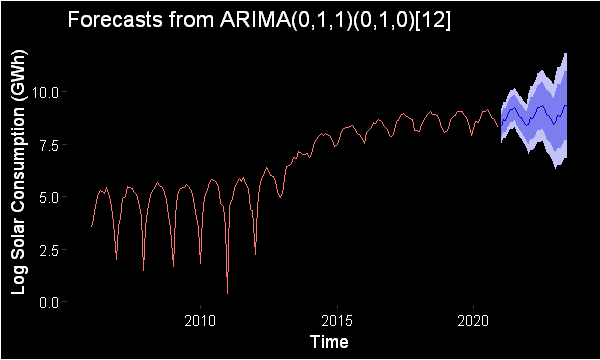

It is clear from the analysis that there are larger factors at play determining trends in this space. For example, the California Solar Initiative has been a crucial driver of solar power growth in the state, and understanding its impact on the industry is essential for making informed predictions. We see a particularly intense spike in solar consumption after the expansion of the Net Metering Program. Under this program, customers with solar panels on their homes or businesses can receive credits for excess electricity they generate and send back to the grid. These credits can then be used to offset the customer’s future electricity bills. The 2013 expansion of the NEM program removed size limitations on eligible systems and allowed customers to receive credits for excess electricity at the retail rate, rather than the lower wholesale rate. This dramatically increased incentives and the results in consumption can be seen below.

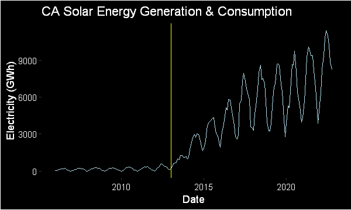

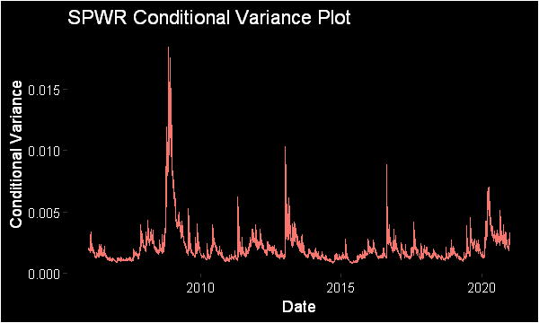

[figure not shown]

In terms of future research directions, it would be interesting to explore the impact of advancements in solar panel technology on solar power generation trends in California. As the technology continues to evolve, it is likely to become even more cost-effective and efficient, potentially leading to further growth in the industry. The government can continue to provide incentives to supercharge this growth, but as the market becomes more mature and these subsidies are relaxed, it will be interesting to monitor.

In conclusion, this analysis highlights the potential of solar power as a crucial solution for reducing greenhouse gas emissions and combating climate change. By understanding the trends and patterns in solar power generation and consumption, policymakers and industry leaders can make informed decisions about how to incentivize and optimize the effectiveness of this year-round renewable energy source.